# ASAM Metadata 2021 Krill Biomass Estimate

Tracey Dornan

09/06/2021

# Krill biomass estimates from ASAM 2021 metadata

This Rmarkdown scripts works with a reduced version of the ASAM 2021 metadata spreadsheet, generated by “ASAM_2021_BiomassSummaryStats.Rmd”. In summary, the original metadata spreadsheet was:

1. formatted to be R friendly
2. cleaned of duplicated data
3. cleaned of data with missing values of Density, CV or Area required in calculations

This script reads in the cleaned data file *“ASAM_metadata_2021_v3_reduced.csv”* and restricts data to area 48.1 only.

### Years & Months available for 48.1 data:

```
##  [1] 1996 1997 1998 1999 2000 2001 2002 2003 2004 2005 2006 2007 2008 2009 2010
## [16] 2011 2012 2013 2014 2015 2016 2018 2019 2020
```

```
## [1] "Apr"             "Aug"             "Dec"             "Dec,Jan,Feb,Mar"
## [5] "Feb"             "Jan"             "Jan, Feb"        "Mar"
```

### Strata available

Strata which did not have a strata code already identified have been assigned one based on the closest area they resemble.

| Stratum_name | Number_surveys | strata_code | Min_Area | Max_Area | Mean_Area |
| --- | --- | --- | --- | --- | --- |
| Elephant Island | 31 | E | 41673 | 48231 | 43752 |
| West | 31 | W | 18870 | 38524 | 34398 |
| South | 26 | S | 8102 | 24479 | 20070 |
| Joinville | 14 | J | 17057 | 18322 | 18066 |
| entire survey area | 1 | WESJ | 115526 | 115526 | 115526 |
| Bransfield | 2 | S | 24479 | 24479 | 24479 |
| South Shetland Islands North | 1 | W | 29031 | 29031 | 29031 |
| AP | 2 | WE | 473318 | 473318 | 473318 |
| SSI | 2 | With_AP_is_WESJ | 48654 | 48654 | 48654 |
| South Shetland Island (SSI) | 1 | W | 120980 | 120980 | 120980 |
| Bransfield Strait (BS) | 6 | S | 22416 | 77707 | 31631 |
| Elephant Island (EL) | 1 | E | 53921 | 53921 | 53921 |

## Biomass calculations

### Strategy

The data will be assessed sequentially starting at the smallest strata combining all data within each of “E”, “W”, “S”, “J” .

Then combining all data with “WE” codes and finally combining all in the large scale full area “WESJ”.

**NOTE: the 2019 synoptic survey was aggregated over “Dec,Jan,Feb,Mar” & data available broadly spans months of Dec-Mar.**

April is represented by a single 2018 survey carried out on *Polarstern*. In addition the CV were simply calculated as the S.E/Mean x 100% for each stratum or entire survey area, which covered: * South Shetland Islands North - W * Elephant Island - E * Bransfield - S * Joinville - J * entire survey area - WESJ

August data was all collected by the *Nathaniel B. Palmer* in 2012, 2014, 2015, 2016

**Given the available data, summary stats are initially being calculated for the combined months of “December, January, February and March” data only.**

### Methodology

**1) identify the various surveys that will be included in computing an average**

**2) compute weighted mean density using the survey areas as weights**

- TotalArea <- sum(Survey_area_km2)
- AreaWeighting := Survey_area_km2/TotalArea
- Mean_Wt_Density_gm2 <- weighted.mean(x =Density_gm2, w = AreaWeighting)

since CVs are reported in the metadata spreadsheet these need to be converted to variances for use in the next step as  
variance of survey density = (reported CV * reported density)<sup>2</sup>

- Var_Density := (Density_gm2 * (CV_of_density_Perc / 100) )^2

**3) compute the variance of the weighted mean density using equation 3 in Jolly and Hampton (1990)**

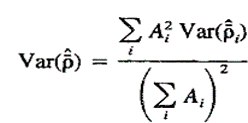

- JH_Numerator := (Survey_area_km2^2 * Var_Density)
- Var_WtMeanDensity <- (sum(tmpdt$JH_Numerator)) / (TotalArea)^2

**4) CV = sqrt of variance from step 3 / mean from step 2**

- CV <- (sqrt(Var_WtMeanDensity) / Mean_Wt_Density_gm2)*100

**5) compute extrapolated biomass estimate as mean from step 2 * area to which extrapolation applies**

(in Tonnes Per Square Kilometer (t/km2))

- biomass_extra <- Mean_Wt_Density_gm2 * mean_strata_area

**6) compute variance of estimate from step 5 as variance from step 3 * (area to which extrapolation applies)<sup>2</sup>**

- var_biomass_extra <- Var_WtMeanDensity *(mean_strata_area^2)

**7) CV = sqrt of variance from step 6 / biomass estimate from step 5**

- CV_of_TotalBiomass <- (sqrt(var_biomass_extra) / biomass_extra)*100

Notes: • Steps 2-3 of this pseudocode can be applied to multiple surveys within a single stratum, surveys that cover multiple strata, or any combination of both. • Steps 3 and 6 aren’t necessary but the results of those two should be equal and provide a nice double-check that everything is working OK. • For those interested in application to the Grym later on - the outcome from Step 7 (or Step 4) might yield a useful estimate of the parameter “B0logSD,” where B0logSD = sqrt(log(1+CV^2))

Step 1 - working by area

**Year codes**

```
y3 =  2020 2019 2018

y5 = 2020 2019 2018 2016 2015

y5107 = 2020 2019 2018 2016 2015 2014 2013 2012 2011 2010 2009

yall = All available =  2020 2019 2018 2016 2015 2014 2013 2012 2011 2010 2009 2008 2007 2006 2005 2004 2003 2002 2001 2000 1999 1998 1997 1996
```

### Joinville

Years available: 2002, 2004, 2005, 2008, 2009, 2010, 2011, 2014, 2015, 2018, 2019

Mean Joinville survey area from all data in analysis: 18066km<sup>2</sup> for extrapolation

```
## [1] "Joinville"
```

```
## [1] 18066.41
```

| Strata | N_surveys | Wt_mean_Density_gm2 | Var_Wt_mean_Density | CV_Wt_mean_Density_Perc | Total_Mean_Area | Biomass_Tonnes_km2 | Years_included |
| --- | --- | --- | --- | --- | --- | --- | --- |
| Joinville | 1 | 83.01 | 723.28 | 32.4 | 18066.41 | 1499723.46 | y3 |
| Joinville | 1 | 83.01 | 723.28 | 32.4 | 18066.41 | 1499723.46 | y5 |
| Joinville | 4 | 51.87 | 187.89 | 26.43 | 18066.41 | 937150.47 | y5107 |
| Joinville | 11 | 29.48 | 28.19 | 18.01 | 18066.41 | 532577.68 | yall |